# Exploratory data analysis: the short version

CNNs are trained to classify single red blood cells from NIH `cell_images` as parasitised or uninfected, then tested without fine-tuning on BBBC041 and MP-IDB. This notebook shows how the three datasets differ and what that means for the method. The summary comes first, and sections 1 to 6 hold the evidence. The full EDA (`01_eda.ipynb`) is the appendix.

| Term | Meaning here |
| --- | --- |
| crop | the image of one cell that the network receives |
| site_a / site_b | BBBC041's two acquisition batches (1,208 PNG and 120 JPG images), reported separately |
| cell only | measured on the cell's own pixels, without black padding or background |
| separation | how reliably one number tells two groups apart: 0 means no better than a coin flip, 1 means always |
| sensitivity / specificity | the share of parasitised cells called parasitised / the share of uninfected cells called uninfected |
| prevalence | the share of cells in a dataset that are parasitised |

## Summary: findings and decisions

| # | Finding | Evidence | Decision for the method |
| --- | --- | --- | --- |
| 1 | Only 2.7% (site_a) and 5.1% (site_b) of BBBC041 cells are parasitised; MP-IDB has no uninfected cells | 1 | Report sensitivity and specificity, never accuracy; specificity only on BBBC041; site_a and site_b separately; BBBC041 difficult and leukocyte cells excluded |
| 2 | NIH is *P. falciparum* only; BBBC041 is *P. vivax* | 1 | BBBC041 results mix a species shift with an imaging shift; MP-IDB *P. falciparum* is the only same-species test set |
| 3 | The NIH split is clean, but average colour alone predicts the NIH label (AUC 0.81) | 2 | Patient-grouped split; NIH-NLM-ThinBloodSmearsPf never a test set; a high NIH score does not prove the model learned the parasite's shape |
| 4 | A quarter of every NIH crop is black padding; test crops have none | 3 | Compare cells on cell pixels; RQ2 step 1 removes the test background (Otsu on brightness) |
| 5 | Every test set is darker than NIH and shifts colour its own way; healthy site_a cells look more "parasitised" than NIH parasites | 4 | RQ2 step 2 matches colour (Reinhard or histogram matching, full EDA section Q); expect lost specificity on site_a |
| 6 | The datasets differ from NIH more than the two classes differ from each other | 5 | RQ1 should find a clear drop |
| 7 | Sharpness differs in both directions | 5 | No blur or noise tests; sharpness remains an uncorrected difference |
| 8 | Removing the background alone makes BBBC041 crops darker than NIH crops | full EDA, section P | Expect little recovery from RQ2 step 1 on BBBC041 |
| 9 | The other species total 140 cells, stage groups are small, and cells cluster in images | 6 | Pool the other species; intervals by resampling images; miss rate per stage; no claims under 30 cells |

## 1. The data

**Question.** How many cells are there, how many are parasitised, and how big are the crops? NIH comes from 200 patients in Bangladesh and was balanced to 50/50 on purpose (Rajaraman et al., 2018). BBBC041 holds *P. vivax* smears (Hung & Carpenter, 2017), and MP-IDB covers four species (Loddo et al., 2019).

| group | images | cells | parasitised | % parasitised | crop_side_px |
| --- | --- | --- | --- | --- | --- |
| NIH | 1408 | 27558 | 13779 | 50.0 | 130.0 |
| BBBC041 site_a | 1208 | 79569 | 2149 | 2.7 | 135.0 |
| BBBC041 site_b | 120 | 5917 | 303 | 5.1 | 172.0 |
| MP-IDB P. falciparum | 104 | 1297 | 1297 | 100.0 | 168.0 |
| MP-IDB P. malariae | 37 | 43 | 43 | 100.0 | 163.0 |
| MP-IDB P. ovale | 29 | 33 | 33 | 100.0 | 201.0 |
| MP-IDB P. vivax | 40 | 64 | 64 | 100.0 | 206.0 |

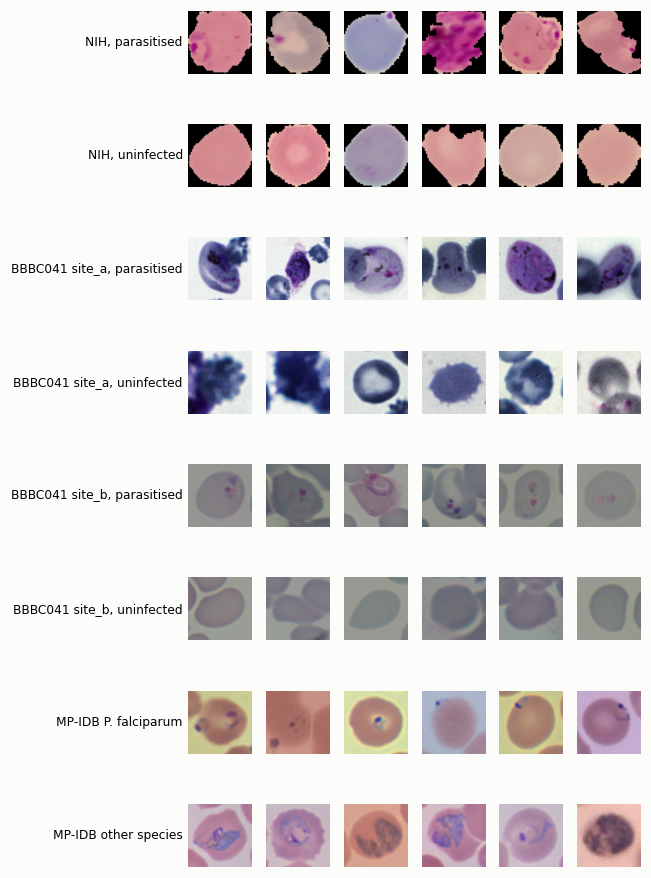

**What this shows.**

- The test sets are mostly uninfected. A model that called every BBBC041 cell uninfected would score 95 to 97% accuracy and find no parasites. MP-IDB has no uninfected cells at all.
- NIH comes from 150 infected patients, all with *P. falciparum* (Rajaraman et al., 2018). BBBC041 is *P. vivax*, so it differs from NIH in species as well as in imaging.
- MP-IDB marks parasites, not cells, so its crops were reframed on the host red cell. BBBC041's `difficult` cells (ambiguous to the annotators) and leukocytes (white blood cells) are set aside.
- NIH cells sit on black; test cells keep their background, and site_a is visibly darker.
- Every crop is resized to 224 px for the network. NIH crops (130 px) are enlarged the most.

## 2. Is the NIH baseline fair?

**Question.** Every drop is measured from the NIH hold-out set, so that value must not be inflated. Cells from one patient share a slide, and splitting by patient lowers accuracy (Rajaraman et al., 2018; Hou et al., 2026).

| label_binary split | parasitised | uninfected | total | patients |
| --- | --- | --- | --- | --- |
| train | 9619 | 9584 | 19203 | 140.0 |
| val | 2105 | 2073 | 4178 | 30.0 |
| test | 2055 | 2122 | 4177 | 30.0 |
| total | 13779 | 13779 | 27558 | 200.0 |

```
NIH label from average cell colour only: AUC = 0.81
```

**What this shows.**

- The split keeps each of the 200 patients on one side, and both classes stay balanced. No image appears twice, and no near-duplicate crosses the split. The NIH-NLM-ThinBloodSmearsPf release holds the same patients (192 of 200; Kassim et al., 2021), so it can never be a test set.
- 19,203 training cells are plenty for fine-tuning networks pretrained on ImageNet.
- Each NIH slide was read by one expert, with no second annotator (Rajaraman et al., 2018). The 11 MP-IDB cells with an unknown stage show up in section 6.
- Average colour alone predicts the label at an AUC of 0.81, because the stain turns parasites purple. A high NIH score therefore does not prove the model learned what a parasite looks like, and colour is exactly what changes between datasets (section 4).

## 3. How were the cells cut?

**Question.** NIH cells were cut out along their outline and placed on black; the test sets have no outlines, so their crops are plain squares. Loddo et al. (2022) noted this difference without testing it, and Zhao et al. (2020) named segmentation as a possible cause of the drop.

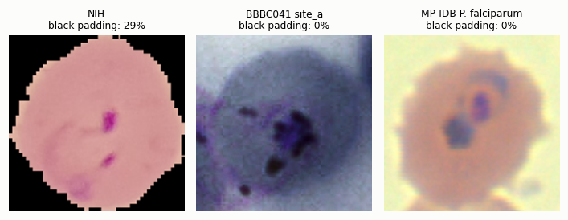

| group | black padding (share) | brightness, whole crop | brightness, inside cell | sharpness, whole crop | sharpness, inside cell |
| --- | --- | --- | --- | --- | --- |
| NIH | 0.26 | 118.55 | 164.68 | 574.84 | 5.78 |
| BBBC041 site_a | 0.00 | 152.31 | 92.54 | 34.66 | 24.29 |
| BBBC041 site_b | 0.00 | 132.06 | 121.94 | 2.81 | 2.49 |
| MP-IDB P. falciparum | 0.00 | 151.41 | 131.27 | 5.74 | 5.31 |
| MP-IDB P. malariae | 0.00 | 151.47 | 110.65 | 46.27 | 45.79 |
| MP-IDB P. ovale | 0.00 | 161.36 | 142.88 | 5.92 | 5.79 |
| MP-IDB P. vivax | 0.00 | 182.30 | 157.08 | 6.07 | 5.75 |

**What this shows.**

- About a quarter of every NIH crop is black (median 26%); no test crop has any.
- The padding turns the comparisons around. Over the whole crop, NIH looks the darkest and about 12 to 200 times sharper, because the edge between cell and black background is the strongest edge in the image. Inside the cell, NIH is the brightest group, and its sharpness falls in the middle of the test groups. Sections 4 and 5 therefore measure the cells themselves.
- Removing the test background works with a simple Otsu brightness threshold: it matches the hand-drawn NIH outlines closely (median Dice overlap 0.90, where 1 is a perfect match). The neural removers U²-Net and IS-Net find no cell in 21% and 49% of cases (full EDA, section P).

## 4. Colour and brightness of the cells

**Question.** Do the cells themselves differ? Stain colour varies between laboratories and is a known reason why CNNs fail on another lab's slides (Tellez et al., 2019). To compare cell with cell, the test cells are shown with their background removed: every parasitised test cell, plus 3,000 uninfected cells per BBBC041 site.

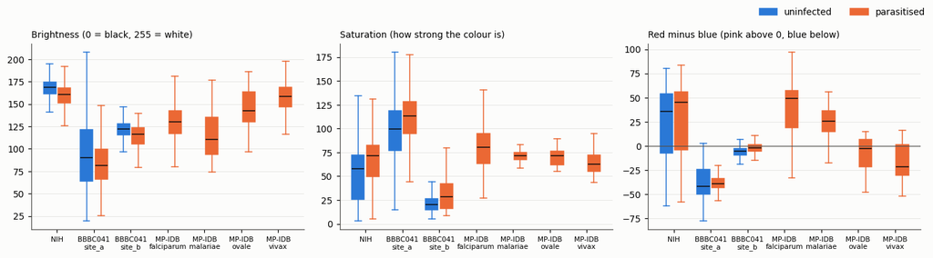

**What this shows.**

- Every test group is darker than NIH. site_a is the darkest (median about 80 to 90, against 160 to 169 for NIH); only *P. vivax* comes close.
- The colour shifts a different way per group: site_a is saturated and blue, site_b nearly grey, *P. falciparum* pink like NIH, *P. vivax* bluish. Splitting the stain into its two dyes shows the same pattern: BBBC041 cells absorbed about three to four times as much blue dye as NIH cells (full EDA, section Q).
- Healthy site_a cells are more saturated (median about 99) than NIH's parasitised cells (about 71), and far bluer. A model that learned "strong purple means parasite" would flag them. That fits Hou et al. (2026), whose NIH-trained model kept 96.4% sensitivity on BBBC041 but reached only 18.0% specificity.

## 5. Sharpness, and datasets against classes

**Question.** The proposal planned to blur and add noise to images to imitate the shift, as robustness studies of NIH cells do (Kanamugire & Djoumessi, 2026). Are the test sets really blurrier? Sharpness is the Laplacian variance: how sharply brightness jumps between neighbouring pixels, measured inside the cell at 224 px.

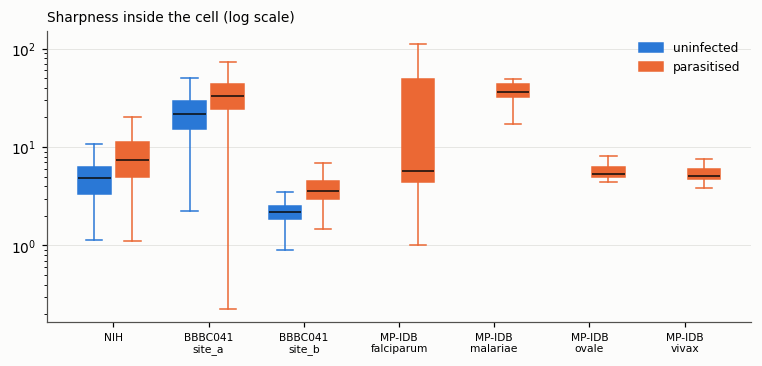

The table puts sections 4 and 5 together. The first row is the difference the model has to learn: parasitised against uninfected NIH cells. Every other row compares a test group with NIH cells of the same class, so it shows the shift between datasets alone.

|  | brightness | saturation | red minus blue | sharpness |
| --- | --- | --- | --- | --- |
| NIH parasitised vs NIH uninfected (the signal) | 0.38 | 0.32 | 0.10 | 0.48 |
| BBBC041 site_a uninfected vs NIH uninfected | 0.85 | 0.71 | 0.89 | 0.97 |
| BBBC041 site_a parasitised vs NIH parasitised | 0.98 | 0.79 | 0.96 | 0.96 |
| BBBC041 site_b uninfected vs NIH uninfected | 0.98 | 0.67 | 0.43 | 0.90 |
| BBBC041 site_b parasitised vs NIH parasitised | 0.96 | 0.70 | 0.50 | 0.70 |
| MP-IDB P. falciparum parasitised vs NIH parasitised | 0.73 | 0.29 | 0.13 | 0.08 |
| MP-IDB P. malariae parasitised vs NIH parasitised | 0.82 | 0.03 | 0.23 | 0.99 |
| MP-IDB P. ovale parasitised vs NIH parasitised | 0.41 | 0.02 | 0.63 | 0.33 |
| MP-IDB P. vivax parasitised vs NIH parasitised | 0.07 | 0.16 | 0.73 | 0.36 |

**What this shows.**

- Sharpness differs in both directions: site_a and *P. malariae* are sharper than NIH, site_b is blurrier, and the other species are close. Blurring NIH cannot imitate that, which is why the blur and noise tests were dropped from RQ2.
- Inside NIH, the two classes reach separations of 0.1 to 0.5. Between NIH and BBBC041, cells of the same class mostly reach 0.7 to 1.0. The shift between datasets is bigger than the signal the model is trained on.

## 6. What RQ3 can support

**Question.** Are there enough parasitised cells per species and life stage to compare sensitivity between them?

| stage group | gametocyte | ring | schizont | trophozoite | unknown | total |
| --- | --- | --- | --- | --- | --- | --- |
| BBBC041 site_a | 144 | 353 | 179 | 1473 | 0 | 2149 |
| BBBC041 site_b | 12 | 169 | 11 | 111 | 0 | 303 |
| MP-IDB P. falciparum | 7 | 1230 | 18 | 42 | 0 | 1297 |
| MP-IDB P. malariae | 8 | 0 | 10 | 21 | 4 | 43 |
| MP-IDB P. ovale | 6 | 10 | 1 | 9 | 7 | 33 |
| MP-IDB P. vivax | 8 | 40 | 11 | 5 | 0 | 64 |
| total | 185 | 1802 | 230 | 1661 | 11 | 3889 |

**What this shows.**

- The other species are small: 140 cells in total. With 30 cells, a measured sensitivity of 90% is compatible with anything from about 74% to 97%.
- Cells cluster in images: the 1,297 *P. falciparum* cells come from only 104 images, up to 67 in one. Intervals must therefore resample images, not cells.
- Trophozoites are 69% of site_a's parasites, so they will cause most misses whatever the model does. The miss rate per stage is the fairer measure.

## Overall suitability

The data suits RQ1 and RQ2 well: the NIH split is clean, the test sets are large, the shift from NIH is large, and both candidate causes can be measured and matched. RQ3 is limited to the pooled species comparison and the more common life stages.

The full EDA also covers duplicates, the NIH source photographs, the background-removal methods and the colour transforms.

## References

Hou, M., He, G., Liu, Z., Huang, J., & Zou, H. (2026). MalariaNet: A microcontroller-deployable malaria-microscopy detector for point-of-care biosensing under leakage-free evaluation. *Biosensors, 16*(7), 358. https://doi.org/10.3390/bios16070358

Hung, J., & Carpenter, A. (2017). Applying Faster R-CNN for object detection on malaria images. In *2017 IEEE Conference on Computer Vision and Pattern Recognition Workshops (CVPRW)* (pp. 808–813). IEEE. https://doi.org/10.1109/CVPRW.2017.112

Kanamugire, O., & Djoumessi, K. (2026). *Beyond accuracy: Evaluating efficiency, robustness and explainability in deep learning for malaria diagnosis* [Preprint]. arXiv. https://doi.org/10.48550/arXiv.2605.30734

Kassim, Y. M., Palaniappan, K., Yang, F., Poostchi, M., Palaniappan, N., Maude, R. J., Antani, S., & Jaeger, S. (2021). Clustering-based dual deep learning architecture for detecting red blood cells in malaria diagnostic smears. *IEEE Journal of Biomedical and Health Informatics, 25*(5), 1735–1746. https://doi.org/10.1109/JBHI.2020.3034863

Loddo, A., Di Ruberto, C., Kocher, M., & Prod'Hom, G. (2019). MP-IDB: The Malaria Parasite Image Database for image processing and analysis. In *Processing and Analysis of Biomedical Information* (Lecture Notes in Computer Science, pp. 57–65). Springer. https://doi.org/10.1007/978-3-030-13835-6_7

Loddo, A., Fadda, C., & Di Ruberto, C. (2022). An empirical evaluation of convolutional networks for malaria diagnosis. *Journal of Imaging, 8*(3), 66. https://doi.org/10.3390/jimaging8030066

Rajaraman, S., Antani, S. K., Poostchi, M., Silamut, K., Hossain, M. A., Maude, R. J., Jaeger, S., & Thoma, G. R. (2018). Pre-trained convolutional neural networks as feature extractors toward improved malaria parasite detection in thin blood smear images. *PeerJ, 6*, e4568. https://doi.org/10.7717/peerj.4568

Tellez, D., Litjens, G., Bándi, P., Bulten, W., Bokhorst, J.-M., Ciompi, F., & van der Laak, J. (2019). Quantifying the effects of data augmentation and stain color normalization in convolutional neural networks for computational pathology. *Medical Image Analysis, 58*, 101544. https://doi.org/10.1016/j.media.2019.101544

Zhao, O. S., Kolluri, N., Anand, A., Chu, N., Bhavaraju, R., Ojha, A., Tiku, S., Nguyen, D., Chen, R., Morales, A., Valliappan, D., Patel, J. P., & Nguyen, K. (2020). Convolutional neural networks to automate the screening of malaria in low-resource countries. *PeerJ, 8*, e9674. https://doi.org/10.7717/peerj.9674